# Data621_Assignment2

Ritesh Lohiya

June 23, 2018

Overview In this homework assignment, you will work through various classification metrics. You will be asked to create functions in R to carry out the various calculations. You will also investigate some functions in packages that will let you obtain the equivalent results. Finally, you will create graphical output that also can be used to evaluate the output of classification models, such as binary logistic regression. #

```r
library(caret)
library(pROC)
```

```r
library(ggplot2)
```

1. Download the classification output data set (attached in Blackboard to the assignment).

```r
data <- read.csv("https://raw.githubusercontent.com/Riteshlohiya/Data621-Assignment2/master/classification-output-data.csv", stringsAsFactors = FALSE, sep = ",", header = TRUE)

summary(data)
```

```
##     pregnant         glucose        diastolic        skinfold
##  Min.   : 0.000   Min.   : 57.0   Min.   : 38.0   Min.   : 0.0
##  1st Qu.: 1.000   1st Qu.: 99.0   1st Qu.: 64.0   1st Qu.: 0.0
##  Median : 3.000   Median :112.0   Median : 70.0   Median :22.0
##  Mean   : 3.862   Mean   :118.3   Mean   : 71.7   Mean   :19.8
##  3rd Qu.: 6.000   3rd Qu.:136.0   3rd Qu.: 78.0   3rd Qu.:32.0
##  Max.   :15.000   Max.   :197.0   Max.   :104.0   Max.   :54.0
##     insulin            bmi           pedigree           age
##  Min.   :  0.00   Min.   :19.40   Min.   :0.0850   Min.   :21.00
##  1st Qu.:  0.00   1st Qu.:26.30   1st Qu.:0.2570   1st Qu.:24.00
##  Median :  0.00   Median :31.60   Median :0.3910   Median :30.00
##  Mean   : 63.77   Mean   :31.58   Mean   :0.4496   Mean   :33.31
##  3rd Qu.:105.00   3rd Qu.:36.00   3rd Qu.:0.5800   3rd Qu.:41.00
##  Max.   :543.00   Max.   :50.00   Max.   :2.2880   Max.   :67.00
##      class         scored.class    scored.probability
##  Min.   :0.0000   Min.   :0.0000   Min.   :0.02323
##  1st Qu.:0.0000   1st Qu.:0.0000   1st Qu.:0.11702
##  Median :0.0000   Median :0.0000   Median :0.23999
##  Mean   :0.3149   Mean   :0.1768   Mean   :0.30373
##  3rd Qu.:1.0000   3rd Qu.:0.0000   3rd Qu.:0.43093
##  Max.   :1.0000   Max.   :1.0000   Max.   :0.94633
```

2. The data set has three key columns we will use: ??? class: the actual class for the observation scored.class: the predicted class for the observation (based on a threshold of 0.5) ??? scored.probability: the predicted probability of success for the observation. Use the table() function to get the raw confusion matrix for this scored dataset. Make sure you understand the output. In particular, do the rows represent the actual or predicted class? The columns?

```r
r <- table(data$scored.class,data$class)
knitr:: kable(r)
```

|  | 0 | 1 |
| --- | --- | --- |
| 0 | 119 | 30 |
| 1 | 5 | 27 |

3. Write a function that takes the data set as a dataframe, with actual and predicted classifications identified, and returns the accuracy of the predictions.

```r
Accuracy <- function(data) {
tb = table(data$class,data$scored.class)
TN=tb[1,1]
TP=tb[2,2]
FN=tb[2,1]
FP=tb[1,2]

return((TP+TN)/(TP+FP+TN+FN))

}
Accuracy(data)
```

```
## [1] 0.8066298
```

4. Write a function that takes the data set as a dataframe, with actual and predicted classifications identified, and returns the classification error rate of the predictions.

```r
CER <- function(data) {
tb = table(data$class,data$scored.class)
TN=tb[1,1]
TP=tb[2,2]
FN=tb[2,1]
FP=tb[1,2]

return((FP+FN)/(TP+FP+TN+FN))

}

CER(data)
```

```
## [1] 0.1933702
```

5. Write a function that takes the data set as a dataframe, with actual and predicted classifications identified, and returns the precision of the predictions.

```r
Precision <- function(data) {
tb = table(data$class,data$scored.class)
TP=tb[2,2]
FP=tb[1,2]

return((TP)/(TP+FP))

}
Precision(data)
```

```
## [1] 0.84375
```

6. Write a function that takes the data set as a dataframe, with actual and predicted classifications identified, and returns the sensitivity of the predictions. Sensitivity is also known as recall.

```r
Sensitivity <- function(data) {
tb = table(data$class,data$scored.class)
TP=tb[2,2]
FN=tb[2,1]

return((TP)/(TP+FN))

}

Sensitivity(data)
```

```
## [1] 0.4736842
```

7. Write a function that takes the data set as a dataframe, with actual and predicted classifications identified, and returns the specificity of the predictions.

```r
Specificity <- function(data) {
tb = table(data$class,data$scored.class)
TN=tb[1,1]
TP=tb[2,2]
FN=tb[2,1]
FP=tb[1,2]

return((TN)/(TN+FP))

}
Specificity(data)
```

```
## [1] 0.9596774
```

8. Write a function that takes the data set as a dataframe, with actual and predicted classifications identified, and returns the F1 score of the predictions.

```r
F1_score <- function(data) {
tb = table(data$class,data$scored.class)
TN=tb[1,1]
TP=tb[2,2]
FN=tb[2,1]
FP=tb[1,2]


Precision = (TP)/(TP+FP)
Sensitivity = (TP)/(TP+FN)
Precision =(TP)/(TP+FP)

return((2*Precision*Sensitivity)/(Precision+Sensitivity))

}
F1_score(data)
```

```
## [1] 0.6067416
```

Both Precision and Sensitivity used to calculate F1 score are bounded between 0 and 1 , so F1 score will be between 0 and 1.

10. Write a function that generates an ROC curve from a data set with a true classification column (class in our example) and a probability column (scored.probability in our example). Your function should return a list that includes the plot of the ROC curve and a vector that contains the calculated area under the curve (AUC). Note that I recommend using a sequence of thresholds ranging from 0 to 1 at 0.01 intervals.

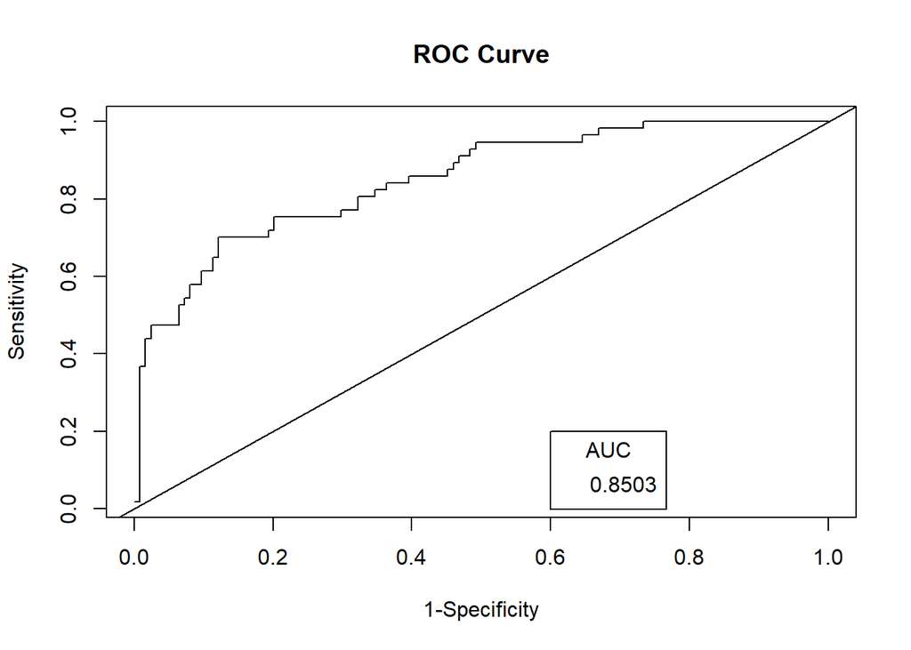

```r
ROC = function(labels, scores){
  labels = labels[order(scores, decreasing=TRUE)]
  result =data.frame(TPR=cumsum(labels)/sum(labels), FPR=cumsum(!labels)/sum(!labels), labels)

  FPR_df = c(diff(result$FPR), 0)
  TPR_df = c(diff(result$TPR), 0)
  AUC = round(sum(result$TPR * FPR_df) + sum(TPR_df * FPR_df)/2,4)

  plot(result$FPR,result$TPR,type="l",main ="ROC Curve",ylab="Sensitivity",xlab="1-Specificity")
  abline(a=0,b=1)
  legend(.6,.2,AUC,title = "AUC")

}

ROC(data$class,data$scored.probability)
```

11. Use your created R functions and the provided classification output data set to produce all of the classification metrics discussed above.

```r
Accuracy(data)
```

```
## [1] 0.8066298
```

```r
CER(data)
```

```
## [1] 0.1933702
```

```r
Precision(data)
```

```
## [1] 0.84375
```

```r
Sensitivity(data)
```

```
## [1] 0.4736842
```

```r
Specificity(data)
```

```
## [1] 0.9596774
```

```r
F1_score(data)
```

```
## [1] 0.6067416
```

12. Investigate the caret package. In particular, consider the functions confusionMatrix, sensitivity, and specificity. Apply the functions to the data set. How do the results compare with your own functions?

```r
confusionMatrix(as.factor(data$scored.class), as.factor(data$class), positive = "1")
```

```
## Confusion Matrix and Statistics
##
##           Reference
## Prediction   0   1
##          0 119  30
##          1   5  27
##
##                Accuracy : 0.8066
##                  95% CI : (0.7415, 0.8615)
##     No Information Rate : 0.6851
##     P-Value [Acc > NIR] : 0.0001712
##
##                   Kappa : 0.4916
##  Mcnemar's Test P-Value : 4.976e-05
##
##             Sensitivity : 0.4737
##             Specificity : 0.9597
##          Pos Pred Value : 0.8438
##          Neg Pred Value : 0.7987
##              Prevalence : 0.3149
##          Detection Rate : 0.1492
##    Detection Prevalence : 0.1768
##       Balanced Accuracy : 0.7167
##
##        'Positive' Class : 1
##
```

The results are similar.

13. Investigate the pROC package. Use it to generate an ROC curve for the data set. How do the results compare with your own functions?

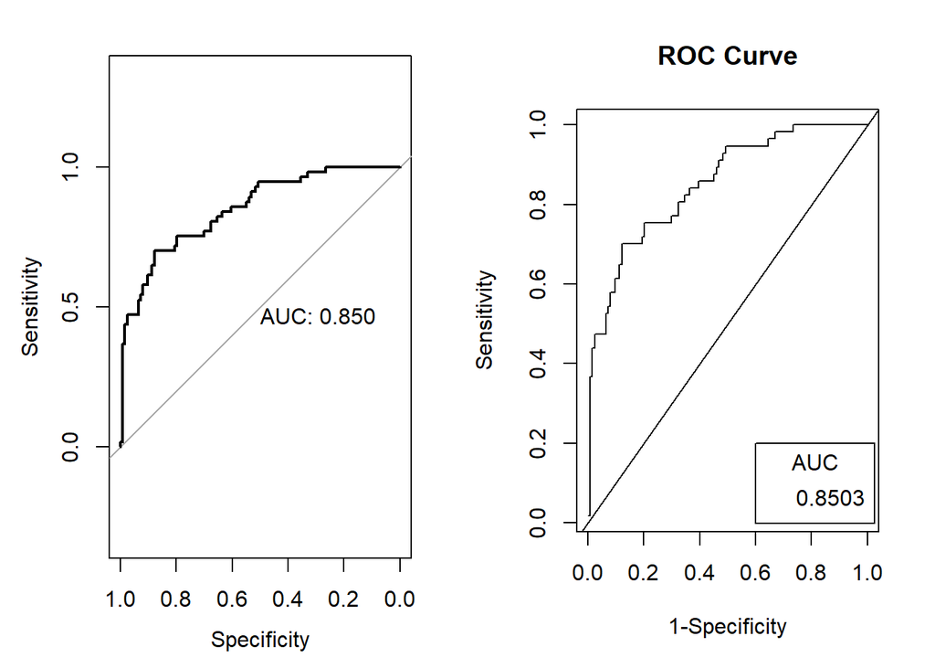

```r
par(mfrow=c(1,2))
plot(roc(data$class,data$scored.probability),print.auc=TRUE)
ROC(data$class,data$scored.probability)
```